# TASK 1 认识网络结构数据

狗熊会

在生活中，我们经常会接触到看得见或是看不见的的网络，比如建立在手机软件上的社交网络、连接大江南北的铁路网络等等，这些有形无形的网络刻画了人与人、城市与城市之间的关联性。在数学上，通过画出点并在点之间建立连接，我们能够抽象出统一的网络结构来对各种各样的事物及其关联性加以研究，探究这些网络所共有的一些性质。通过今后的几个TASK，我们将走近网络结构数据，并学习从这种数据中发现结论和价值的方法。

**任务介绍**：在这一个TASK里面我们来认识网络结构数据，了解和网络结构数据相关的基本概念。

这个案例的学习目标包括：

1. 了解什么是网络，网络由什么组成。
2. 学习网络的分类（有向/无向，有权/无权）。
3. 了解网络结构数据的应用场景。

### 准备工作

```r
#清除工作环境
cat("\014");rm(list=ls())
```

```r
#加载相应的包
library(igraph)
```

### 任务一: 学习网络的定义

网络用于表示诸多个体及其相互联系。一个网络中包含一系列的节点，这些节点通过某种关系（又称“边”）互相连接。

**节点（node/vertex）：**网络的基本观察单位。在一般的复杂网络中，节点可以是任何东西，例如在微信用户网络里,节点可以是微信账号的持有人。在研究以进出口贸易衡量的国际关系网络时，节点可以是全球的各个国家。

**边（link/edge/tie）：**节点之间的关系。例如，将市场上的所有投资者都看作节点，则一条连接两个人的边可以用来表示这两名投资者之间进行过至少一笔交易。

节点之间的关系可以是多维度的，并且可以囊括一系列不同的关系类型。网络分析所使用的数据集一般包括最少两组数据集，一组包含了所有的节点，另一组则给出这些节点之间的互动关系（常见的形态是邻接矩阵和边列表）。

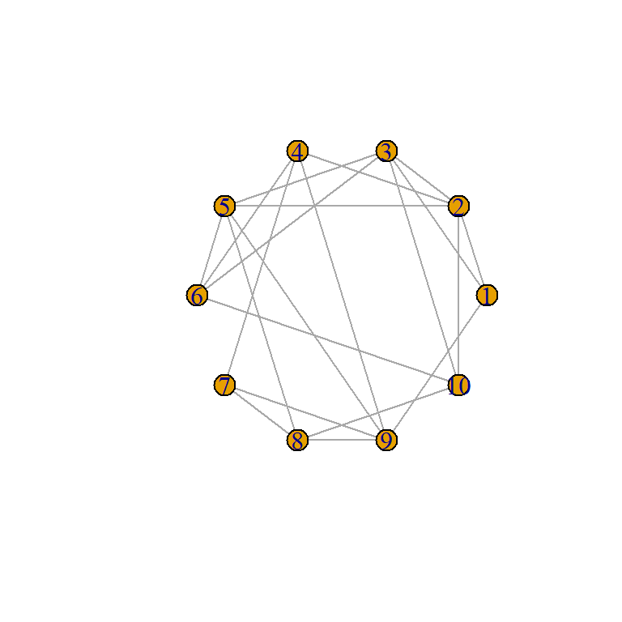

### 任务二: 根据边有无方向和有无权重将网络进行分类

节点之间的联系多种多样，它们之间的关系并不一定是相互的。根据边有无方向可以将网络分为**有向网络（directed network）**和**无向网络（undirected network）**。有向网络中所有的边都有方向，此时一对节点之间的关系往往是非对称的。以雇佣关系为例，雇主A对雇员B的“发放薪资”的关系可以用一条由A指向B的有向边表示，其中节点A是薪资的发送者，节点B是薪资的接受者。应当注意，当我们考察“汇报工作”这一关系时，雇主A也可以成为接受者，这表明在有向图中不仅要注意方向，更要注意声明有向边的含义。无向网络中的关系则不需要区分方向，例如同学关系、伙伴关系、婚姻关系。

网络分析中还可以对边进行赋权，根据有无权重将网络分为**有权网络（weighted network）**和无权网络**（unweighted network）**。常见的对边加权的方式有：

1. 用数值标明边的权重，例如使用相关系数，在实际问题中还可能为损耗系数等（交通运输网络中的传输消耗）
2. 用两个节点之间所连的边的数量作为权重（例如合作过的作品数量）

### 任务三: 介绍生活中常见的网络结构数据

在日常生活中常见的网络数据有很多，现举例说明其中一些有向、无向网络及有权重、无权重的网络。

同学关系构成的网络是一种无向、无权重的网络，如图1.1所示。在图1.1中每一个节点代表一个学生，每一条边所连接的两个节点（学生）之间存在同学关系。显然同学关系是一个无向的关系，即“学生1与学生2是同学”和“学生2与学生1是同学”之间并没有区别。

基于“引用论文”这一关系构成的网络是一种有向网络，如图1.2所示。图1.2中的每一个节点代表一名公开发表过学术文章的学者，而一条由A指向B的有向的边则表示“A引用过B的文章”。这种引用关系是有向的，当A引用过B的文章时，B未必反过来引用过A的文章。注意到图1.2中A和D之间存在互相引用过彼此文章的关系，这被称为双向关系。

演员之间合作电影的网络是一种有权网络，将合作过的电影数量作为权重赋给边，得到图1.3。图1.3中每一个节点代表一个演员，每一条边表示其所连接的两个节点（演员）之间合作过电影，而这一条边的权重就是边上所标示的合作过的电影数量。

例1.1和1.2中所展示的矩阵为邻接矩阵，邻接矩阵具体的含义及使用我们将在下一个TASK中详细介绍。

```r
set.seed(1)                                                               #固定随机种子，使得结果可重复
data = matrix(sample(0:1, 100, replace=TRUE, prob=c(0.5,0.5)), nrow=10)   #创建数据
data[lower.tri(data)] = t(data)[lower.tri(data)]                          #将矩阵对称化
for(i in 1:10){　　　　　　　　　　　　　　　　　　　　　　               #剔除节点指向自己的情形
  data[i,i] = 0}
data
```

```
##       [,1] [,2] [,3] [,4] [,5] [,6] [,7] [,8] [,9] [,10]
##  [1,]    0    1    0    1    0    1    0    1    1     1
##  [2,]    1    0    1    0    0    0    1    0    0     1
##  [3,]    0    1    0    1    0    1    1    1    1     0
##  [4,]    1    0    1    0    0    1    1    1    1     0
##  [5,]    0    0    0    0    0    1    0    1    0     0
##  [6,]    1    0    1    1    1    0    1    0    1     0
##  [7,]    0    1    1    1    0    1    0    0    0     1
##  [8,]    1    0    1    1    1    0    0    0    1     1
##  [9,]    1    0    1    1    0    1    0    1    0     0
## [10,]    1    1    0    0    0    0    1    1    0     0
```

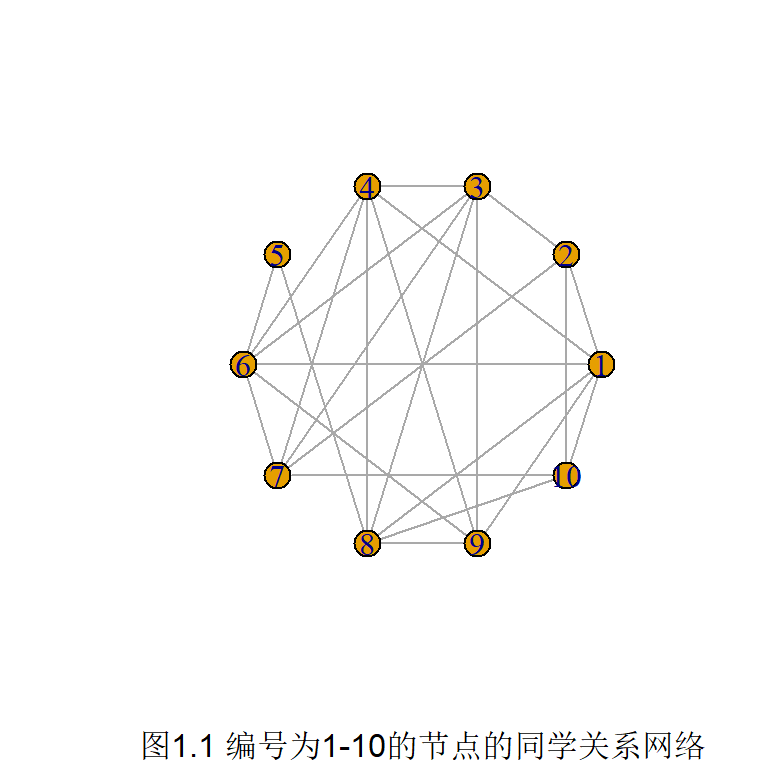

```r
network = graph_from_adjacency_matrix(data , mode='undirected', diag=F )   #创建网络
plot(network, layout=layout.circle, sub ="图1.1 编号为1-10的节点的同学关系网络")
```

```r
set.seed(2)                                                 #固定随机种子，使得结果可重复
data = matrix(sample(0:1, 36, replace=TRUE), nrow=6)　　　　#创建数据
colnames(data) = rownames(data) = LETTERS[1:6]　　　　　　　#创建网络
for(i in 1:6){　　　　　　　　　　　　　　　　　　　　　　 #剔除节点指向自己的情形
  data[i,i] = 0}
data
```

```
##   A B C D E F
## A 0 0 1 1 0 0
## B 0 0 0 1 0 1
## C 1 0 0 0 1 0
## D 1 1 0 0 0 1
## E 1 0 1 0 0 1
## F 1 0 1 1 1 0
```

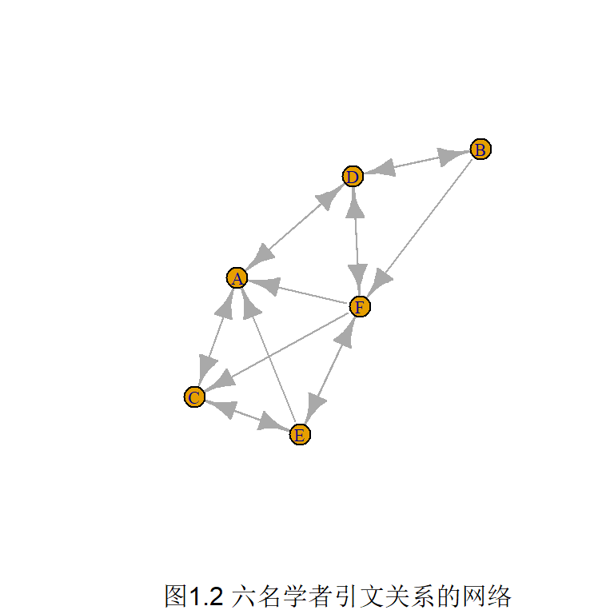

```r
network = graph_from_adjacency_matrix(data)
plot(network,
     vertex.label.cex=.7,      #节点的标签字号
     vertex.label.dist=.01,    #节点的标签的位置
     sub = "图1.2 六名学者引文关系的网络")
```

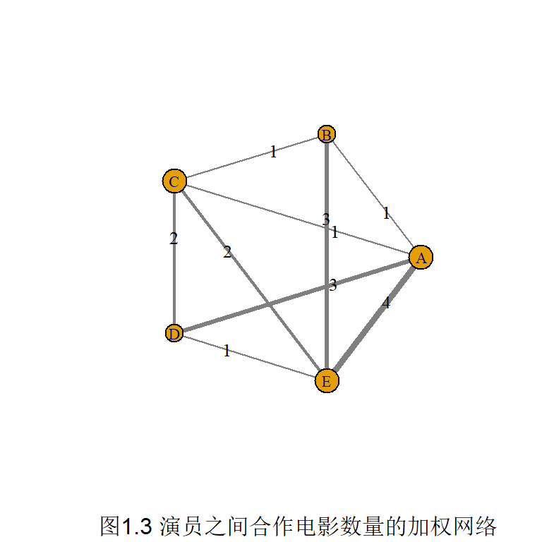

```r
name1 = c("A","A","A","A","B","B","C","C","D")
name2 = c("B","C","D","E","C","E","D","E","E")
weight = c(1,1,3,4,1,3,2,2,1)
data = data.frame(name1 = name1,name2 = name2,weight = weight)  #建立数据，其中第三列为权重
network = graph_from_data_frame(
  d=data,vertices=c("A","B","C","D","E"),
  directed=F)
deg=degree(network,mode="all")
E(network)$width=E(network)$weight #边的宽度由权重决定

plot(network,
     vertex.size=5*deg,      #点的度数越大，绘制的点越大
     vertex.label.cex=.7,    #节点的标签字号
     vertex.label.dist=.01,  #节点的标签的位置
     layout=layout.circle,   #环形布局
     edge.label = weight,    #标记边的权重
     edge.label.cex = .8,    #标记边权的字号
     edge.label.color = "black", #边权字体颜色
     edge.color="gray50",    #边的颜色
     sub = "图1.3 演员之间合作电影数量的加权网络")
```

### 课后作业

举个网络结构数据的例子，说明该网络结构数据中点、边的含义，并且写一写有什么应用。